# Data Analytics Use Cases

## Tech Futures Lab

Dr John Graves

17 Nov 2021

## About Me

- Computer Scientist by training turned to Data Science about 8 years ago
- Worked across several industries such as consulting, telco, marketing
- In my current role I work for a global fitness company - Les Mills International

## Exploratory Data Analysis

## Exploratory Data Analysis

Summarise the main characteristics of a dataset in the context of a business problem, market or customer base

- Very common analytics use case usually undertaken at the beginning of a company’s data strategy
- Involves visual methods and statistical modelling to identify outliers, trends and patterns in the data that merits further study
- Results generally delivered in the form of reports, slides and web pages

## Example EDA based on Public Dataset

[Example Analysis](http://jg1141.github.io/slides/reports/analysis-flight-report.html)

## Customer Churn Modelling

## Customer Churn Modelling

Prevent customer churn by targeting customers identified as high-risk churn candidates

- Still one of the most typical analytics use cases in many industries  
  (especially in the telecommunication and energy sector)
- Churn projects are often part of a bigger retention strategy involving related data projects such as
  - Customer profiling
  - Customer segmentation
  - Customer surveys
  - Analysis of customer service interactions

## What Data is Used for the Modelling?

- **Customer “dimensions”**  
  Age, gender, marital status, home address, phone number
- **Customer Behaviour**  
  Types of services used, service frequency, spending, spending patterns, recency, service usage patterns, customer service interactions, tenure
- **Supporting datasets**  
  Public [census data](https://www.stats.govt.nz/tools/2018-census-place-summaries/auckland-region), commercial socio-economic datasets (e.g. [Helix Personas](http://www.roymorgan.com/products/helix-personas)), social media data

## Definition of Churn

- No clear churn definition or event due to prepaid services, low usage or seasonal usage frequencies, “tourist usage”
- Historic services and/or business model changes
- Not all customers are equally valueable (specific customer churn might be economically acceptable)
- Churn “notice period” – how long in advance do we need to predict churn?

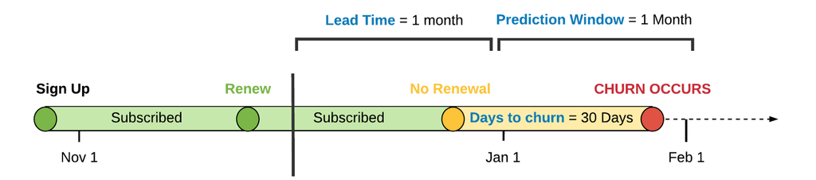

## Modelling Data Set

| Customer ID | Age | Tenure | Total Spend | … | **Churn** |
| --- | --- | --- | --- | --- | --- |
| 12345 | 35 | 175 | $352 | … | **yes** |
| 12346 | 21 | 27 | $52 | … | **no** |
| 12347 | 43 | 691 | $752 | … | **no** |
| … | … | … | … | … | … |

## Data Preparation

Creating the modelling dataset is the most time consuming part of the project:

- **Technical challenges**  
  Customer behaviour is extracted from transactional data which is often huge requiring the use of big data tools
- **Security/access challenges**  
  Data stored in live, operation-critical DBs limiting access for analysts
- **Operational challenges**  
  Data preparation needs to be automated to ensure timely model refreshes

## Machine Learning

### Supervised Learning

**Learning a function** that maps an input to an output based on the **example input-output pairs** in the modelling dataset.

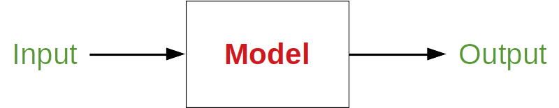

Input is the data of a customer and the output is the churn label (also often a probability of churn).

## Model Building

- Churn data is often highly **imbalanced** – there are fewer churners that non-churners
- Black box models unsuitable as knowing the **reason of churn** is important to prevent it
- Model building needs to be automated for timely model refreshes

## Model Performance

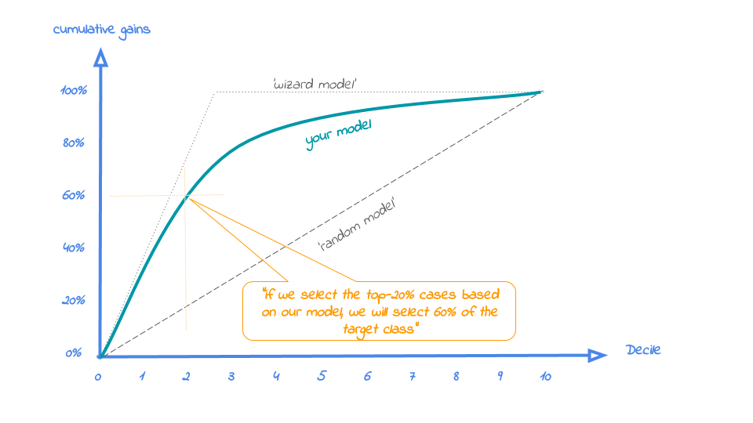

## Model Integration

How are churn model predictions used?

- To retain customers the model needs to provide information on the reason of churn
- Predictions need to be linked with other systems to automatically respond to high-risk customers
- Wider team is required to effectively exploit the churn model predictions

## Summary

- Data on customer behaviour enriched with various other datasets are used to predict and prevent customer churn
- Business domain knowledge is required to precisely define the churn event
- Building and operationalising the model requires several technical functions of a business
- The model needs integration with other systems to be useful

## Analysing Survey Data

## Surveying Data Scientists

[figure not shown]

Download from http://bit.ly/2017-ds-survey

[www.oreilly.com/data/free/2017-data-science-salary-survey.csp]

## Salary Model

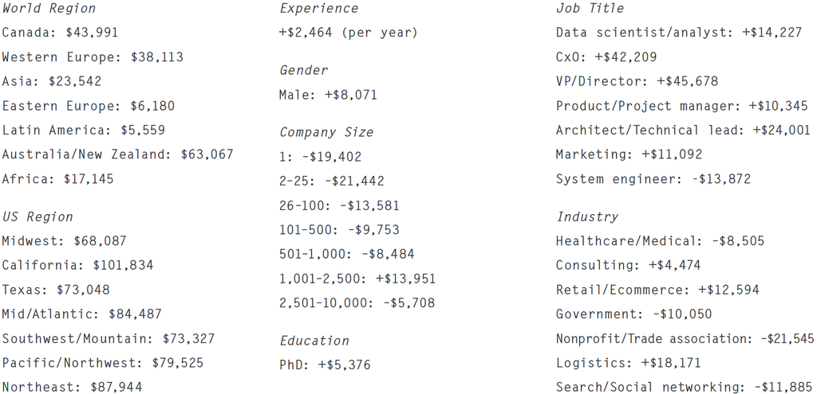

[source: www.oreilly.com/data/free/2017-data-science-salary-survey.csp]

## Summary

## Course Material

bit.ly/dsa-analytics-use-cases

bit.ly/dsa-example-analysis

bit.ly/2017-ds-survey